## Digitale Medien

- Rasanter Wandel & wachsendes Forschungsaufkommen (Scheiter, 2021)
- Anforderung an (angehende) Lehrpersonen & Lehrerbildner:innen (BMBF, 2019, 2018; KMK, 2019, 2016)
- bisher nur wenig systematisch im Lehrpersonenbildungssystem verankert (Monitor Lehrerbildung, 2021)  
  informelle Lernsettings als integrale Ressource
- Bislang: fragmentierte und isolierte deutschsprachige Angebote

## Informationsangebot

### TüDi-BASE

[figure not shown]

- forschungsbasiert: Aufbereitung von **Forschungs-synthesen** (APA, 2006; Burns et al., 2011)
- spezifisch: Themenkomplex “**Digitalisierung** in der Lehrpersonenbildung”
- Zielgruppen: (angehende) **Lehrpersonen** und **Lehrpersonenbildner:innen**

## Aufbau & Begleitforschung

## Selektion

### Themen

**Themencluster**  
„Lernen mit digitalen Medien“ & „Medienbildung“ (BMBF, 2019, 2018; KMK, 2019, 2016)  
**Themenauswahl**

- normativ (“top-down”) auf Basis konzeptueller Rahmenmodelle (z.B. DigCompEdu) (Caena & Redecker, 2019; European Commission, 2017)
- “bottom-up”: systematische Analyse einschlägiger Datenbanken (Web of Science, ERIC)

## Selektion

### Forschungssynthesen

**Eigene Erstellung** von Forschungssynthesen, z.B.

- Learning by teaching on video (Lachner, Hoogerheide, van Gog & Renkl, 2021)
- Combining real and virtual experiments in science education (Wörner, Kuhn & Scheiter, accepted)
- Computer-based feedback on writing (Wagner, Schneider & Lachner, in prep.)

**Standards:**

Template zur Präregistrierung (Schneider et al., 2022)

## Selektion

### Forschungssynthesen

**Bestehende Forschungssynthesen**

1. Relevanzdimensionen
   - Aktueller Diskurs in Öffentlichkeit (und Forschung)
   - Umsetzbarkeit in Schule/Unterricht
   - Innovationspotential
2. Qualität der Forschungssynthese (Study DIAD)
   - Präzision in Interventionen und Operationalisierung
   - Klarheit in der Schlussfolgerung
   - Generalisierbarkeit der Ergebnisse
   - Präzision der Schlussfolgerung

(Valentine & Cooper, 2008)

## Gestaltungsprinzipien

Design

- Einfachheit und Klarheit in der Sprache (Kerwer et al., 2021; McNamara, 2013; Scharrer et al., 2021)
- Verwendung von “Hedges” (Braun & Nückles, 2014)

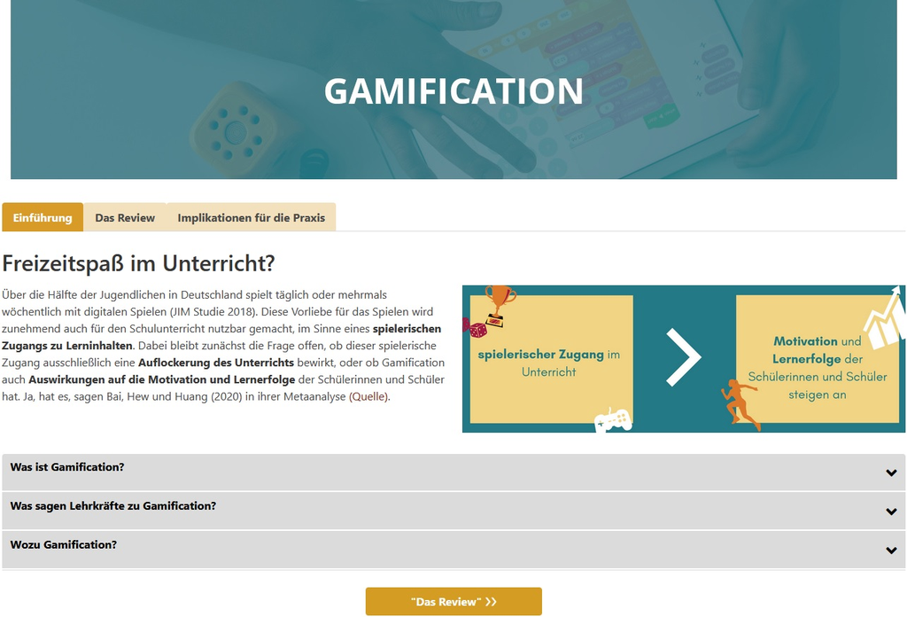

www.tuedilb-tuebingen.de/gamification.html

## Gestaltungsprinzipien

Design  
Begleitforschung

- Einfachheit und Klarheit in der Sprache (Kerwer et al., 2021; McNamara, 2013; Scharrer et al., 2021)
- Verwendung von “Hedges” (Braun & Nückles, 2014)

Laut-Denken  
Studie

Eyetracking  
Studie

Design  
Begleitforschung

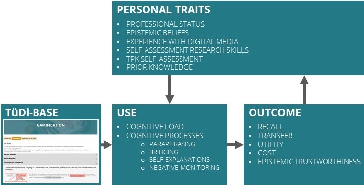

Laut-Denken  
Studie

Eyetracking  
Studie

Präregistrierung: doi.org/10.17605/OSF.IO/5UCTY

## Inhaltliche Komponenten

Design

1. Einführung, Definition, Relevanzinduktion (McCrudden et al., 2011)
2. Erkenntnisse der Forschungsynthese & deren Kontext
3. Evaluation der Forschungssynthese (Hendriks & Jucks, 2020)
4. Implikationen für die Praxis & Tools

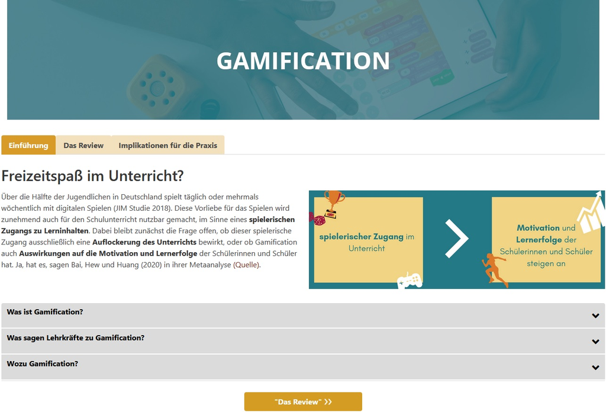

## Inhaltliche Komponenten

Design  
Begleitforschung

1. Einführung, Definition, Relevanzinduktion (McCrudden et al., 2011)
2. Erkenntnisse der Forschungsynthese & deren Kontext
3. Evaluation der Forschungssynthese (Hendriks & Jucks, 2020)
4. Implikationen für die Praxis & Tools

RCTs:  
systematische Variation  
von Komponenten

Design  
Begleitforschung

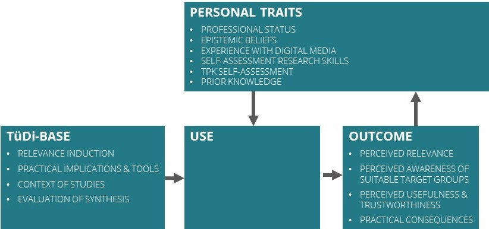

RCTs:  
systematische Variation  
von Komponenten

## Effektstärken

Design

- Interpretation und Verständnis einer Effektgröße als große Herausforderung
  - alternative Effektstärkemaße (Hanel et al., 2019;  
    Lortie-Forgues et al., 2021)
  - Standardisierte Maße nicht greifbar (Lipsey et al., 2012)
  - nicht-standardisierte Maße problematisch (Baird & Pane, 2019; Kraft, 2020)
- grafische Darbietung

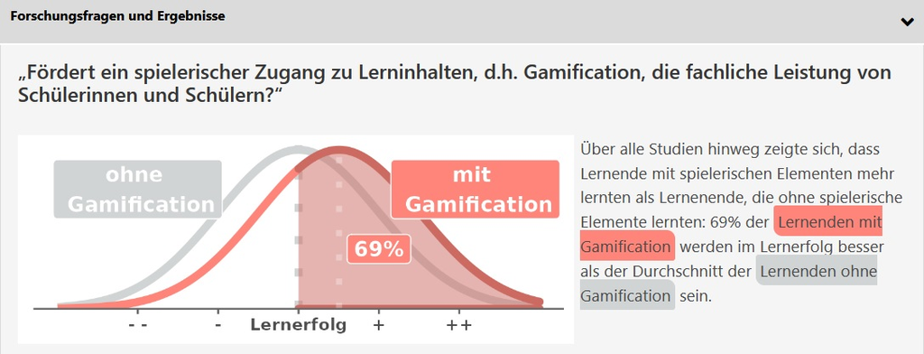

## Effektstärken

Design  
Begleitforschung

- Interpretation und Verständnis einer Effektgröße als große Herausforderung
  - alternative Effektstärkemaße (Hanel et al., 2019;  
    Lortie-Forgues et al., 2021)
  - Standardisierte Maße nicht greifbar (Lipsey et al., 2012)
  - nicht-standardisierte Maße problematisch (Baird & Pane, 2019; Kraft, 2020)
- grafische Darbietung

Delphi & RCTs:  
Effektstärken verständlich  
visualisieren

## Effektstärken

Design  
Begleitforschung

**Studie 1:** (Delphi-Studie)

- **4 Experten** in Data Visualization
- Phase 1: Sammlung von **16 Visualisierungstypen**  
  (für Gruppenscores auf metrischer Variable)

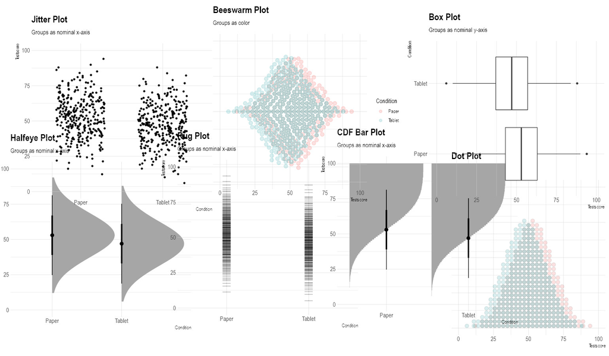

## Effektstärken

Design  
Begleitforschung

**Studie 1:** (Delphi-Studie)

- **4 Experten** in Data Visualization
- Phase 1: Sammlung von **16 Visualisierungstypen**  
  (für Gruppenscores auf metrischer Variable)
- Phase 2: Rating und Ranking von **44 Visualisierungen**  
  (meist 3 Arten der Gruppenunterscheidung)

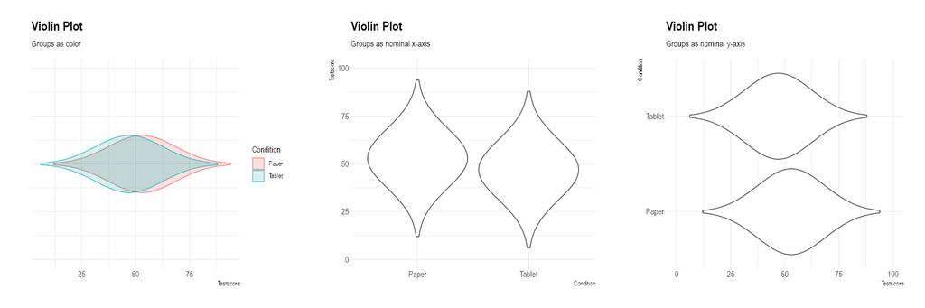

## Effektstärken

Design  
Begleitforschung

**Studie 1:** (Delphi-Studie)

- **4 Experten** in Data Visualization
- Phase 1: Sammlung von **16 Visualisierungstypen**  
  (für Gruppenscores auf metrischer Variable)
- Phase 2: Rating und Ranking von **44 Visualisierungen**  
  (meist 3 Arten der Gruppenunterscheidung)

*“How accurately might teachers assess the effect size depicted in the plot above?”*  
(7-stufige Likert Skala; totally random - totally accurate)

## Effektstärken

Design  
Begleitforschung

**Studie 1:** (Delphi-Studie)

- **4 Experten** in Data Visualization
- Phase 1: Sammlung von **16 Visualisierungstypen**  
  (für Gruppenscores auf metrischer Variable)
- Phase 2: Rating und Ranking von **44 Visualisierungen**  
  (meist 3 Arten der Gruppenunterscheidung)

*“How accurately might teachers assess the effect size depicted in the plot above?”*  
(7-stufige Likert Skala; totally random - totally accurate)

**Ergebnisse: Top 4**

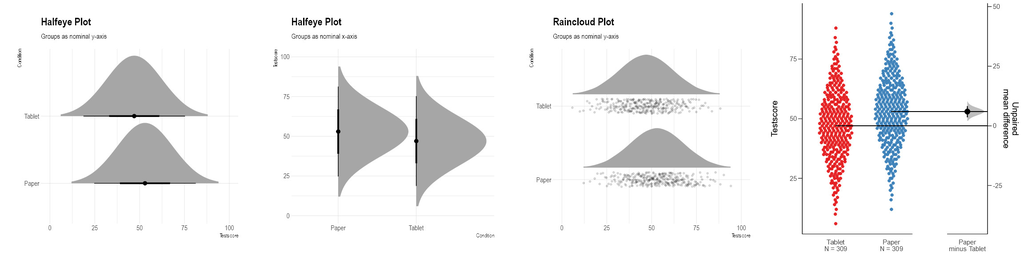

## Effektstärken

Design  
Begleitforschung

**Studie 2:** (RCT)

- **UV**: Vergleich der Top 4 **Visualisierungstypen**  
  (Vignettenbasiert, z.B. digitales vs. analoges Lesen)
- **AVs**:
  - *Sensitivität*
  - *Akkuratheit*
  - *Effizienz*
  - Einschätzung handlungsnaher Konsequenzen
  - Relevanzeinschätzung
  - Wahrscheinlichkeit die Intervention in der Praxis umzusetzen
  - Cognitive Load
- **KVs**:
  - Confirmation Bias
  - Rotation der Größe des Effekts
  - Rotation der Vignetten

## Effektstärken

Design  
Begleitforschung

**Studie 3:** (RCT)

- **UV**: Vergleich von **Anreicherungsoptionen**  
  (z.B. Benchmarks ja/nein; Grafik/Text/Integriert)
- **AVs**:
  - *Sensitivität*
  - *Akkuratheit*
  - *Effizienz*
  - Einschätzung handlungsnaher Konsequenzen
  - Relevanzeinschätzung
  - Wahrscheinlichkeit die Intervention in der Praxis umzusetzen
  - Cognitive Load
- **KVs**:
  - Confirmation Bias
  - Rotation der Größe des Effekts
  - Rotation der Vignetten

## Diskussion

## Diskussion

- TüDi-BASE: spezifisches Angebot zur informellen Fortbildung
- aktuell 5 Forschungssynthesen aufbereitet, stetiger Ausbau
- Generierung und Aufbereitung eigener Forschnugssynthesen
- systematische Begleitforschung

www.tuedilb-tuebingen.de/tuedi-base.html

## Vielen Dank

**Jürgen Schneider**  
juergen.schneider@uni-tuebingen.de

APA. (2006). Evidence-based practice in psychology. *American Psychologist*, *61*(4), 271–285. https://doi.org/10.1037/0003-066X.61.4.271

Baird, M. D., & Pane, J. F. (2019). Translating Standardized Effects of Education Programs Into More Interpretable Metrics. *Educational Researcher*, *48*(4), 217–228. https://doi.org/10.3102/0013189X19848729

BMBF. (2019). *DigitalPakt Schule 2019 bis 2024*.

BMBF. (2018). *Bekanntmachung. Richtlinie zur Förderung von Projekten in der ,,Qualitätsoffensive Lehrerbildung“ mit den Schwerpunkten ,,Digitalisierung in der Lehrerbildung“ und/oder ,,Lehrerbildung für die beruflichen Schulen“*.

Braun, I., & Nückles, M. (2014). Scholarly Holds Lead Over Popular and Instructional: Text Type Influences Epistemological Reading Outcomes: TEXT TYPE INFLUENCES EPISTEMOLOGICAL READING OUTCOMES. *Science Education*, *98*(5), 867–904. https://doi.org/10.1002/sce.21117

Burns, P. B., Rohrich, R. J., & Chung, K. C. (2011). The levels of evidence and their role in evidence-based medicine. *Plastic and Reconstructive Surgery*, *128*(1), 305–310. https://doi.org/10.1097/PRS.0b013e318219c171

Caena, F., & Redecker, C. (2019). Aligning teacher competence frameworks to 21st century challenges: The case for the European Digital Competence Framework for Educators ( *Digcompedu**)* . *European Journal of Education*, *54*(3), 356–369. https://doi.org/10.1111/ejed.12345

European Commission. (2017). *European framework for the digital competence of educators: DigCompEdu.* Publications Office.

Hanel, P. H. P., Maio, G. R., & Manstead, A. S. R. (2019). A new way to look at the data: Similarities between groups of people are large and important. *Journal of Personality and Social Psychology*, *116*(4), 541–562. https://doi.org/10.1037/pspi0000154

Hendriks, F., & Jucks, R. (2020). Does Scientific Uncertainty in News Articles Affect Readers’ Trust and Decision-Making? *Media and Communication*, *8*(2), 401. https://doi.org/10.17645/mac.v8i2.2824

Kerwer, M., Chasiotis, A., Stricker, J., Günther, A., & Rosman, T. (2021). Straight From the Scientist’s MouthPlain Language Summaries Promote Laypeople’s Comprehension and Knowledge Acquisition When Reading About Individual Research Findings in Psychology. *Collabra: Psychology*, *7*(1), 18898. https://doi.org/10.1525/collabra.18898

KMK. (2019). *Standards für die Lehrerbildung: Bildungswissenschaften* [InternetDocument].

KMK. (2016). *Bildung in der digitalen Welt. Strategie der Kultusministerkonferenz*.

Kraft, M. A. (2020). Interpreting Effect Sizes of Education Interventions. *Educational Researcher*, *49*(4), 241–253. https://doi.org/10.3102/0013189X20912798

Lipsey, M. W., Puzio, K., Yun, C., Herbert, M. A., Steinka-Fry, K., Cole, M. W., Roberts, M., Anthony, K. S., & Busick, M. D. (2012). *Translating the Statistical Representation of the Effects of Education Interventions Into More Readily Interpretable Forms* (Institute of Education Sciences, Ed.).

Lortie-Forgues, H., Sio, U. N., & Inglis, M. (2021). How Should Educational Effects Be Communicated to Teachers? *Educational Researcher*, 0013189X2098785. https://doi.org/10.3102/0013189X20987856

McCrudden, M. T., Magliano, J. P., & Schraw, G. J. (Eds.). (2011). *Text relevance and learning from text*. Information Age Pub.

McNamara, D. S. (2013). The epistemic stance between the author and reader: A driving force in the cohesion of text and writing. *Discourse Studies*, *15*(5), 579–595. https://doi.org/10.1177/1461445613501446

Scharrer, L., Bromme, R., & Stadtler, M. (2021). Information Easiness Affects Non-experts’ Evaluation of Scientific Claims About Which They Hold Prior Beliefs. *Frontiers in Psychology*, *12*, 678313. https://doi.org/10.3389/fpsyg.2021.678313

Scheiter, K. (2021). Lernen und Lehren mit digitalen Medien: Eine Standortbestimmung. *Zeitschrift für Erziehungswissenschaft*, *24*(5), 1039–1060. https://doi.org/10.1007/s11618-021-01047-y

Schneider, J., Backfisch, I., & Lachner, A. (2022). Facilitating Open Science Practices for Research Syntheses: PreregRS Guides Preregistration. *Research Synthesis Methods*, *13*(2), 284–289. https://doi.org/10.1002/jrsm.1540

Valentine, J. C., & Cooper, H. (2008). A systematic and transparent approach for assessing the methodological quality of intervention effectiveness research: The Study Design and Implementation Assessment Device (Study DIAD). *Psychological Methods*, *13*(2), 130–149. https://doi.org/10.1037/1082-989X.13.2.130

**Icons:**

Icons by Font Awesome CC BY 4.0